# DATA 624 Project 1

Monu Chacko

4/8/2021

```r
library("readxl")
library("dplyr")
library("tidyr")
library("plotly")
library("forecast")
library("fpp2")
library("lubridate")
library("knitr")
```

## Part A – ATM Forecast

*Here we load the data and clean it up. This includes removing NA’s, putting correct data formats etc.*

```r
atmdata <- read_xlsx("data/ATM624Data.xlsx")
print(str(atmdata))
```

```
## Classes 'tbl_df', 'tbl' and 'data.frame':    1474 obs. of  3 variables:
##  $ DATE: num  39934 39934 39935 39935 39936 ...
##  $ ATM : chr  "ATM1" "ATM2" "ATM1" "ATM2" ...
##  $ Cash: num  96 107 82 89 85 90 90 55 99 79 ...
## NULL
```

```r
atmdata$DATE = as.Date(atmdata$DATE, origin = "1899-12-30")
atmdata = atmdata[!is.na(atmdata$ATM),]

kable(head(atmdata))
```

| DATE | ATM | Cash |
| --- | --- | --- |
| 2009-05-01 | ATM1 | 96 |
| 2009-05-01 | ATM2 | 107 |
| 2009-05-02 | ATM1 | 82 |
| 2009-05-02 | ATM2 | 89 |
| 2009-05-03 | ATM1 | 85 |
| 2009-05-03 | ATM2 | 90 |

```r
kable(summary(atmdata))
```

|  | DATE | ATM | Cash |
| --- | --- | --- | --- |
|  | Min. :2009-05-01 | Length:1460 | Min. : 0.0 |
|  | 1st Qu.:2009-07-31 | Class :character | 1st Qu.: 0.5 |
|  | Median :2009-10-30 | Mode :character | Median : 73.0 |
|  | Mean :2009-10-30 | NA | Mean : 155.6 |
|  | 3rd Qu.:2010-01-29 | NA | 3rd Qu.: 114.0 |
|  | Max. :2010-04-30 | NA | Max. :10919.8 |
|  | NA | NA | NA’s :5 |

*We can compare the data using histogram. This will show us what time of data we are dealing with.*

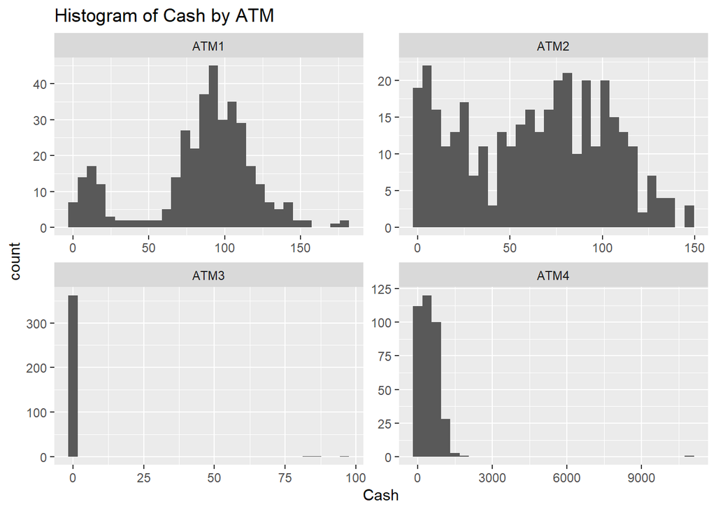

```r
ggplot(atmdata) + geom_histogram(aes(x = Cash)) +
    facet_wrap(~ ATM, scales = "free") +
    labs(title = "Histogram of Cash by ATM")
```

*From the above histogram it is clear we have some issues with ATM 3 and 4. ATM 1 and 2 seem okay.*

```r
atm1 = atmdata %>% filter(ATM=="ATM1") %>% replace_na(list(Cash=0)) %>% select(-DATE,-ATM) %>%  ts(start=c(2009,as.numeric(format(as.Date("2009-05-01"), "%j"))), frequency = 365)
kable(head(atm1))
```

| Cash |
| --- |
| 96 |
| 82 |
| 85 |
| 90 |
| 99 |
| 88 |

```r
atm2 = atmdata %>% filter(ATM=="ATM2") %>% replace_na(list(Cash=0)) %>% select(-DATE,-ATM) %>%  ts(start=c(2009,as.numeric(format(as.Date("2009-05-01"), "%j"))), frequency = 365)
kable(head(atm2))
```

| Cash |
| --- |
| 107 |
| 89 |
| 90 |
| 55 |
| 79 |
| 19 |

```r
atm3 = atmdata %>% filter(ATM=="ATM3",Cash>0) %>% replace_na(list(Cash=0)) %>%select(-DATE,-ATM) %>%   ts(start=c(2010,as.numeric(format(as.Date("2010-04-28"), "%j"))),end=c(2010,as.numeric(format(as.Date("2010-04-30"), "%j"))) ,frequency = 365)
kable(head(atm3))
```

| Cash |
| --- |
| 96 |
| 82 |
| 85 |

```r
atm4 = atmdata %>% filter(ATM=="ATM4") %>% replace_na(list(Cash=0)) %>%select(-DATE,-ATM) %>%  ts(start=c(2009,as.numeric(format(as.Date("2009-05-01"), "%j"))), frequency = 365)
kable(head(atm4))
```

| Cash |
| --- |
| 776.99342 |
| 524.41796 |
| 792.81136 |
| 908.23846 |
| 52.83210 |
| 52.20845 |

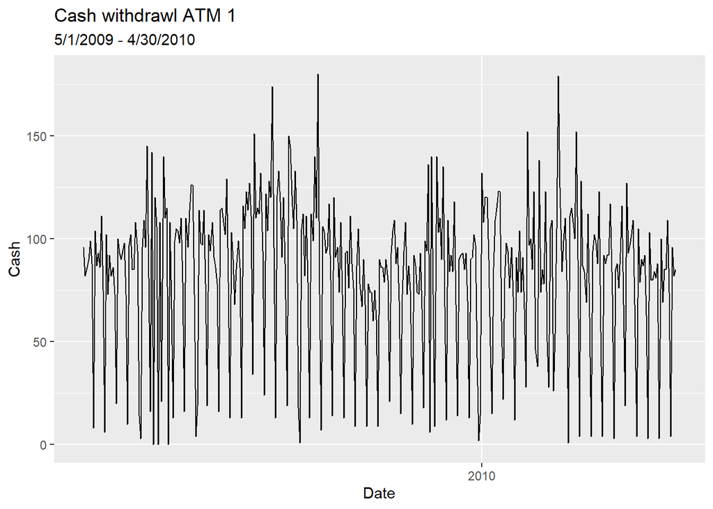

```r
autoplot(atm1) +
  labs(title = "Cash withdrawl ATM 1",
       subtitle = "5/1/2009 - 4/30/2010",
       x = "Date",y = "Cash")
```

```r
print(atmdata)
```

```
## # A tibble: 1,460 x 3
##    DATE       ATM    Cash
##    <date>     <chr> <dbl>
##  1 2009-05-01 ATM1     96
##  2 2009-05-01 ATM2    107
##  3 2009-05-02 ATM1     82
##  4 2009-05-02 ATM2     89
##  5 2009-05-03 ATM1     85
##  6 2009-05-03 ATM2     90
##  7 2009-05-04 ATM1     90
##  8 2009-05-04 ATM2     55
##  9 2009-05-05 ATM1     99
## 10 2009-05-05 ATM2     79
## # ... with 1,450 more rows
```

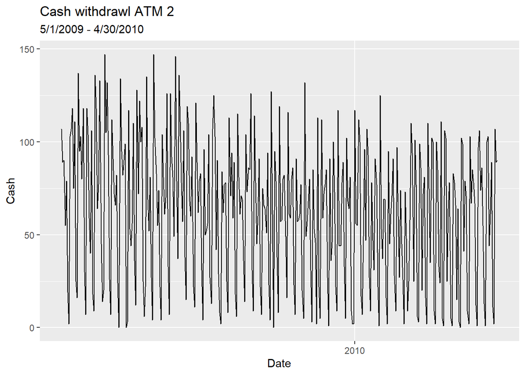

```r
autoplot(atm2) +
  labs(title = "Cash withdrawl ATM 2", subtitle = "5/1/2009 - 4/30/2010",
       x = "Date",y = "Cash")
```

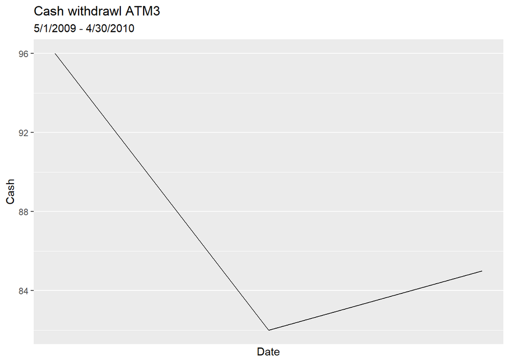

```r
autoplot(atm3) +
  labs(title = "Cash withdrawl ATM3",
       subtitle = "5/1/2009 - 4/30/2010",
       x = "Date",y = "Cash")
```

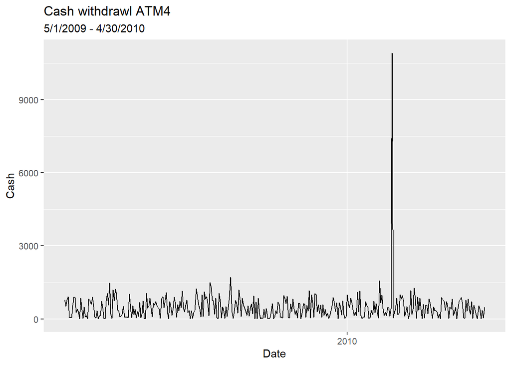

```r
autoplot(atm4) +
  labs(title = "Cash withdrawl ATM4",
       subtitle = "5/1/2009 - 4/30/2010",
       x = "Date",y = "Cash")
```

*Comparing all 4 charts we can visually identify the underlying data. ATM 1 & 2 seems to have similar pattern. ATM 3 has some issues. Looks like there could be problems with the data like missing values etc. ATM 4 seems okay except for the spike. This datapoint has to be further investigated.*

### ATM 1

```r
ATM1_Train = atmdata %>% filter(ATM=="ATM1")%>%replace_na(list(Cash=0)) %>% select(-DATE,-ATM) %>%  ts(start=c(2009,as.numeric(format(as.Date("2009-05-01"), "%j"))),end=c(2010,as.numeric(format(as.Date("2010-03-30"), "%j"))), frequency = 365)

ATM1_Train
```

```
## Time Series:
## Start = c(2009, 121)
## End = c(2010, 89)
## Frequency = 365
##   [1]  96  82  85  90  99  88   8 104  87  93  86 111  75   6 102  73  92  82
##  [19]  86  73  20 100  93  90  94  98  73  10  97 102  85  85 108  94  14   3
##  [37]  96 109  96 145  81  16 142   0 120 106   0 108  21 140 110 115   0 108
##  [55]  66  13  99 105 104  98 110  79  16 110  96 114 126 126  73   4  19 114
##  [73]  98  97 114  78  19 102  94 108  91  86  78  16 114 115 108 102 129  79
##  [91]  13 103  90  68  85  99  86  13 116 105 123 114 127 111  34 151 110 115
## [109] 112 132  94  24 122 104 128 120 174  96  13 121 133 118  91 120  88  19
## [127] 150 144 121 105 133 109  18   1 105 112  82 111  79  13 112  99 140 110
## [145] 180  73   7 106 103  93  96 117  80  14 120  91  96  74 108  73  13  93
## [163]  94  76 111  88  76   9  87 105  78  67  90  68   9  78  74  74  60  75
## [181]  61   9  90  86  86  79  90  80  21  93 104 109  88  96  70  15  73  94
## [199] 108  73  87  75  10  92  87  74  73  93  66  18  99  94 136   6 140  73
## [217]   9 140 103 110  90 135  67  12 109  84  92  84 118  68  14  90  92  93
## [235]  85  93  70  13  90  91 102  97  42   2  14 132 108 120 120  90  48  15
## [253]  86 109 115 123 123  60  22  81  98  94  76  96  72  12  91  74 104  74
## [271]  91  66  28 152  97 100  85 123  46  38 138  74  85  78 123  50  28 105
## [289] 109  26  54 105 179 125  84  99 110  80   1 111 115 108 100 152  90   4
## [307] 128  87  84  69 112  62   4  94 102  98  88 123  55   4  92  88  92  92
## [325] 117  73   3  85  88  76  93 116  68  19
```

```r
ATM1_Test = atmdata %>% filter(ATM=="ATM1")%>%replace_na(list(Cash=0)) %>%select(-DATE,-ATM) %>%  ts(start=c(2010,as.numeric(format(as.Date("2010-03-31"), "%j"))),end=c(2010,as.numeric(format(as.Date("2010-04-30"), "%j"))), frequency = 365)
ATM1_Test
```

```
## Time Series:
## Start = c(2010, 90)
## End = c(2010, 120)
## Frequency = 365
##  [1]  96  82  85  90  99  88   8 104  87  93  86 111  75   6 102  73  92  82  86
## [20]  73  20 100  93  90  94  98  73  10  97 102  85
```

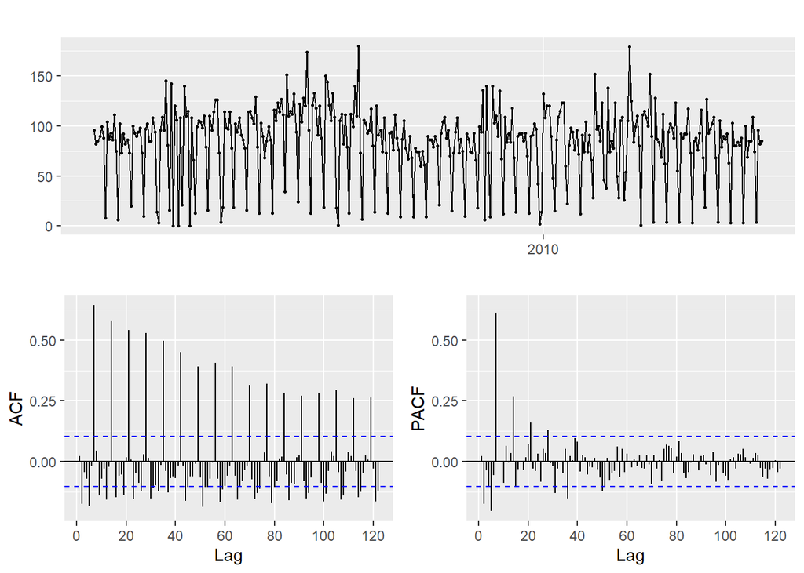

```r
ggtsdisplay(atm1)
```

*Residuals are not normally distributed. The model did not pass the Ljung-Box test. We have to take a look at the intervals. It may not require a lambda value. The model chosen by the function is ETS(A,N,N)*

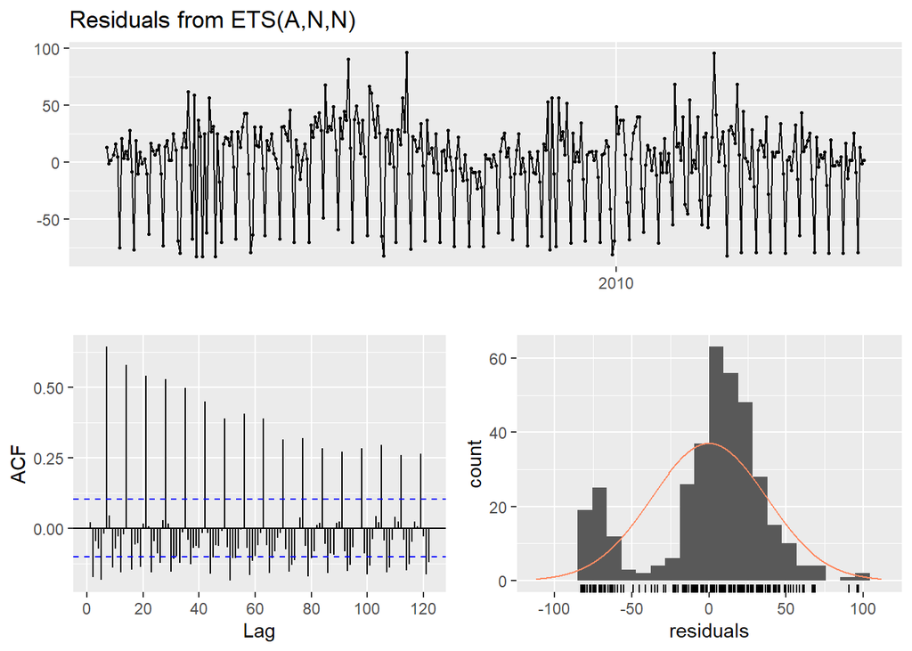

```
##
##  Ljung-Box test
##
## data:  Residuals from ETS(A,N,N)
## Q* = 1181.4, df = 71, p-value < 2.2e-16
##
## Model df: 2.   Total lags used: 73
```

```r
Model1_ATM1 = ets(atm1,lambda=BoxCox.lambda(atm1))
checkresiduals(Model1_ATM1)
```

*The AIC is 4800.063, AICc is 4800.129 and BIC is 4811.763. The RMSE is 37.23543*

```r
summary(Model1_ATM1)
```

```
## ETS(A,N,N)
##
## Call:
##  ets(y = atm1, lambda = BoxCox.lambda(atm1))
##
##   Box-Cox transformation: lambda= 1
##
##   Smoothing parameters:
##     alpha = 1e-04
##
##   Initial states:
##     l = 82.1827
##
##   sigma:  37.3379
##
##      AIC     AICc      BIC
## 4800.063 4800.129 4811.763
##
## Training set error measures:
##                        ME     RMSE      MAE  MPE MAPE MASE       ACF1
## Training set -0.003393192 37.23543 27.94454 -Inf  Inf  NaN 0.02153731
```

*The ETS model fails to capture data trend*

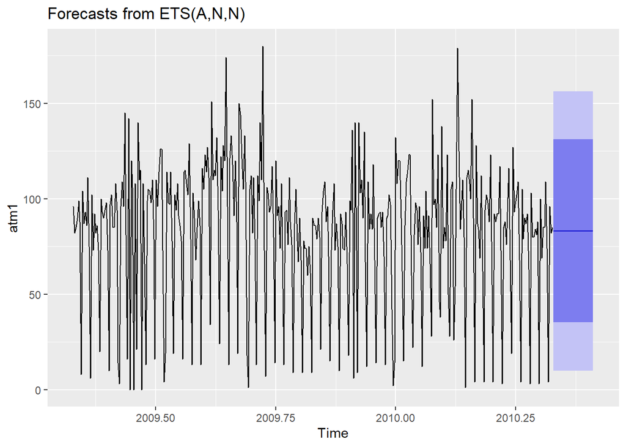

```r
autoplot(forecast(Model1_ATM1, 31))
```

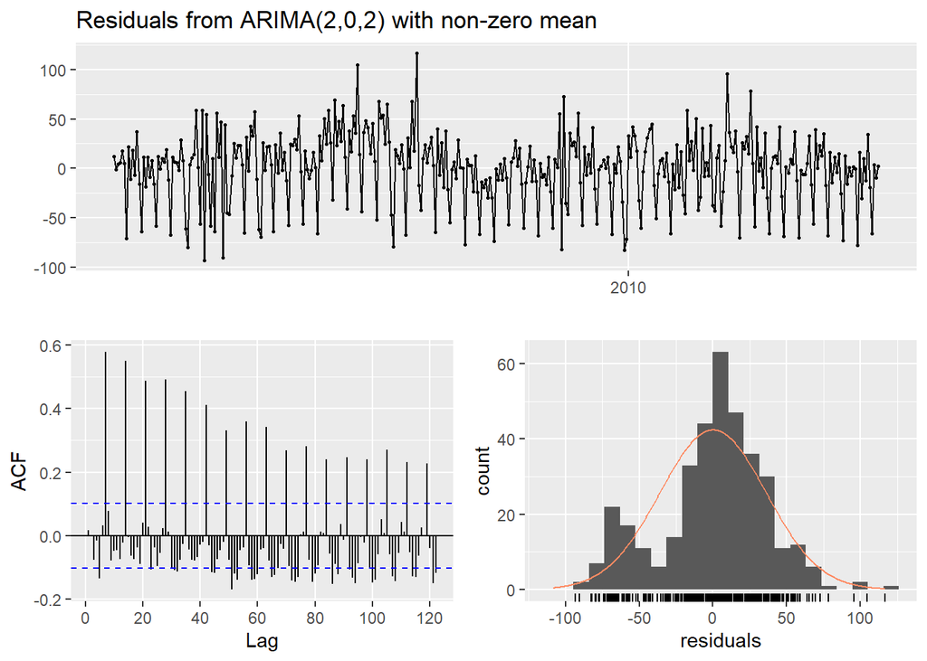

```
##
##  Ljung-Box test
##
## data:  Residuals from ARIMA(2,0,2) with non-zero mean
## Q* = 949.44, df = 68, p-value < 2.2e-16
##
## Model df: 5.   Total lags used: 73
```

```r
Model2_ATM1 =auto.arima(atm1,lambda=BoxCox.lambda(atm1))
checkresiduals(Model2_ATM1)
```

*From the summary we see AIC is 3665.1, AICc is 3665.34 and BIC is 3688.5. The Root Mean Squared Error (RMSE) is 36.0517*

```r
summary(Model2_ATM1)
```

```
## Series: atm1
## ARIMA(2,0,2) with non-zero mean
## Box Cox transformation: lambda= 1
##
## Coefficients:
##           ar1     ar2     ma1      ma2     mean
##       -0.2414  0.3195  0.2672  -0.5364  82.1961
## s.e.   0.1282  0.1107  0.1105   0.0987   1.4986
##
## sigma^2 estimated as 1318:  log likelihood=-1826.55
## AIC=3665.1   AICc=3665.34   BIC=3688.5
##
## Training set error measures:
##                      ME    RMSE      MAE  MPE MAPE MASE       ACF1
## Training set 0.01600632 36.0517 27.43585 -Inf  Inf  NaN 0.01751342
```

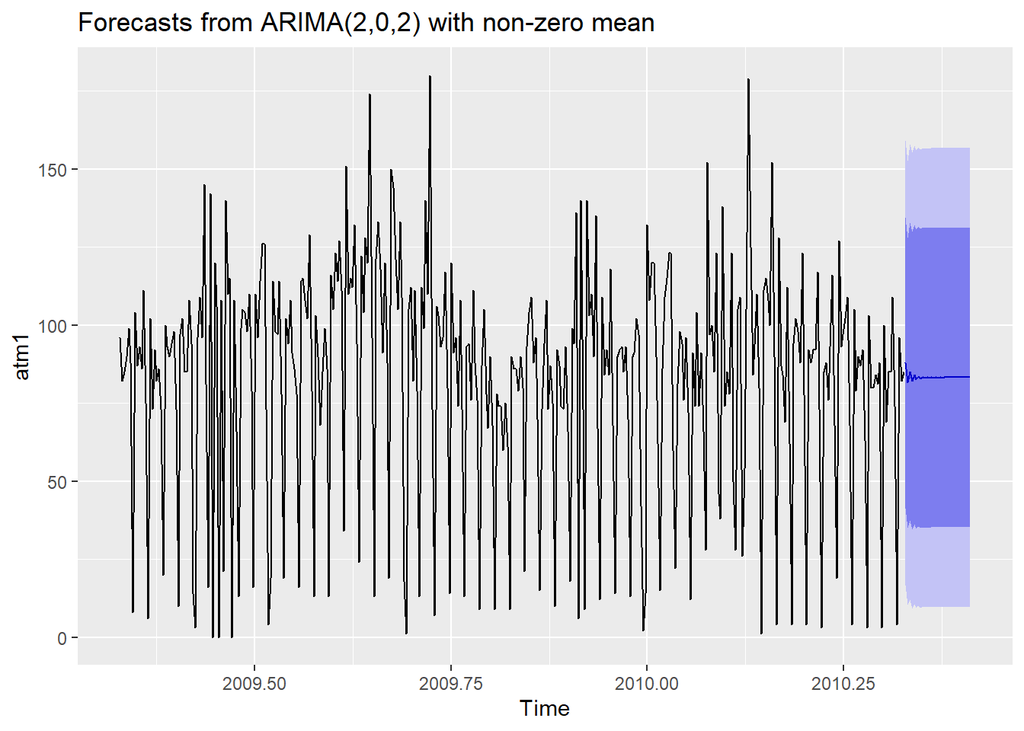

```r
autoplot(forecast(Model2_ATM1, 31))
```

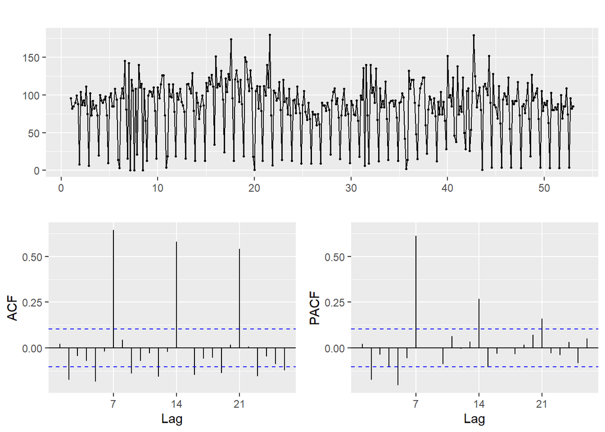

```r
ATM1_Weekly = ts(atm1, frequency = 7)

ggtsdisplay(ATM1_Weekly)
```

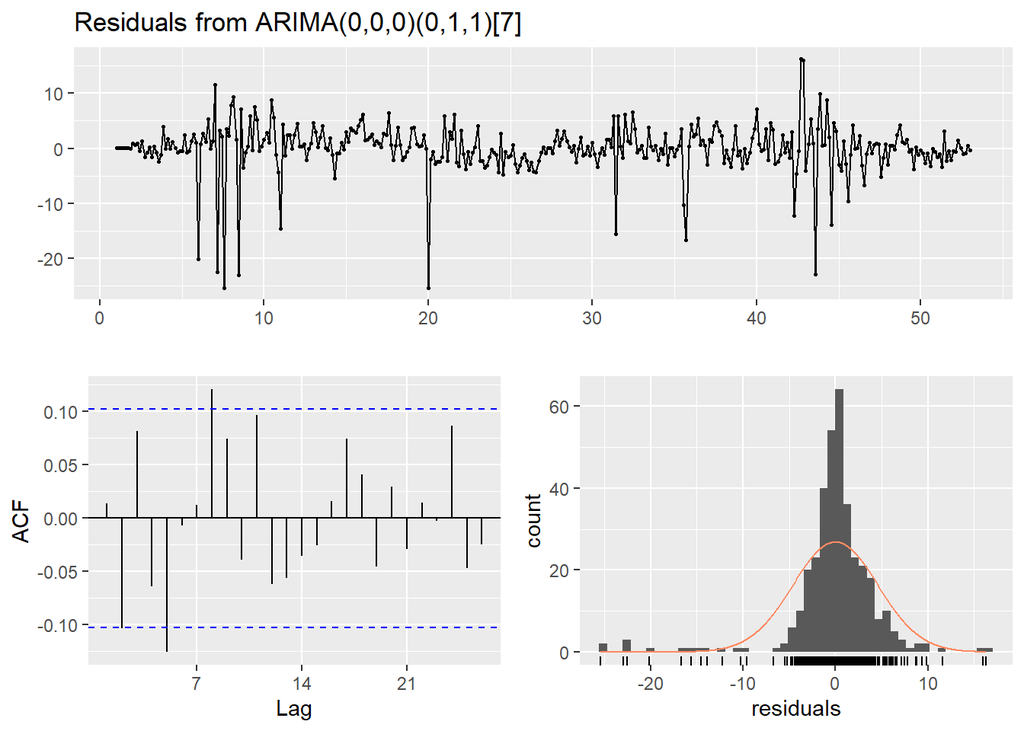

```
##
##  Ljung-Box test
##
## data:  Residuals from ARIMA(0,0,0)(0,1,1)[7]
## Q* = 28.916, df = 13, p-value = 0.006729
##
## Model df: 1.   Total lags used: 14
```

```r
Model3_ATM1_Weekly = auto.arima(ATM1_Weekly,lambda=BoxCox.lambda(ATM1_Weekly))

checkresiduals(Model3_ATM1_Weekly)
```

```r
summary(Model3_ATM1_Weekly)
```

```
## Series: ATM1_Weekly
## ARIMA(0,0,0)(0,1,1)[7]
## Box Cox transformation: lambda= 0.5621795
##
## Coefficients:
##          sma1
##       -0.6947
## s.e.   0.0398
##
## sigma^2 estimated as 21.79:  log likelihood=-1061.35
## AIC=2126.7   AICc=2126.73   BIC=2134.46
##
## Training set error measures:
##                    ME     RMSE      MAE  MPE MAPE      MASE       ACF1
## Training set 1.885474 26.69451 17.00408 -Inf  Inf 0.8841626 0.06009574
```

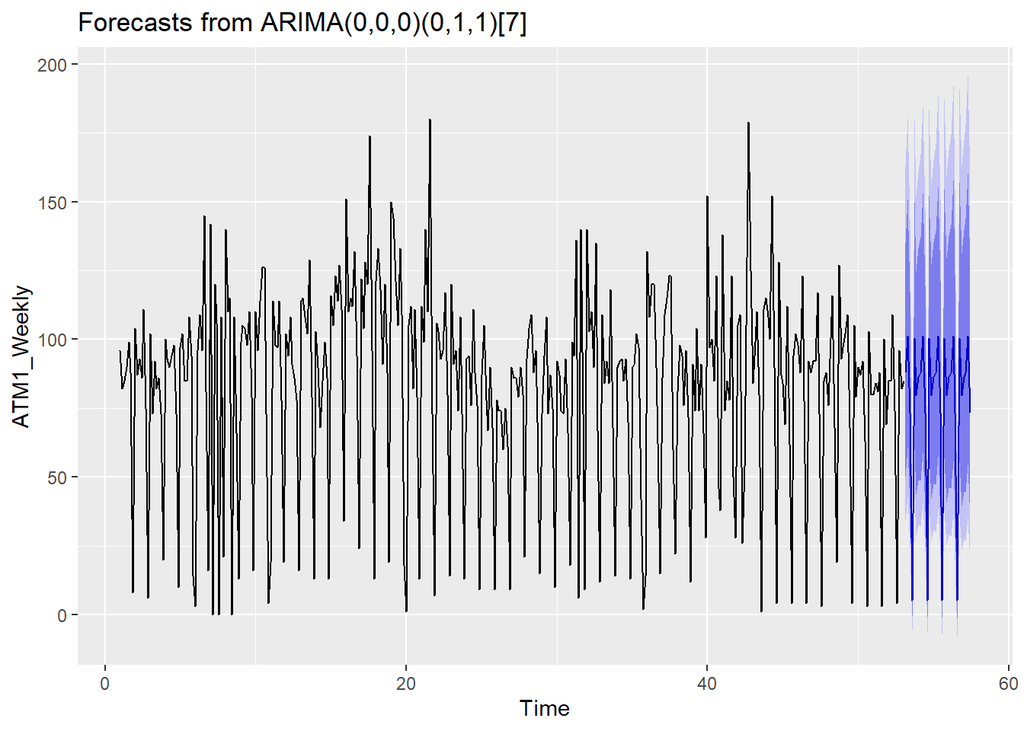

```r
autoplot(forecast(Model3_ATM1_Weekly, 31))
```

```r
ATM1_Forecast = forecast(Model3_ATM1_Weekly, 31, level = 95)

F_ATM1 =data_frame(DATE = rep(max(atmdata$DATE) + 1:31),
           ATM = rep("ATM1"),
           Cash = as.numeric( ATM1_Forecast$mean))
```

### ATM 2

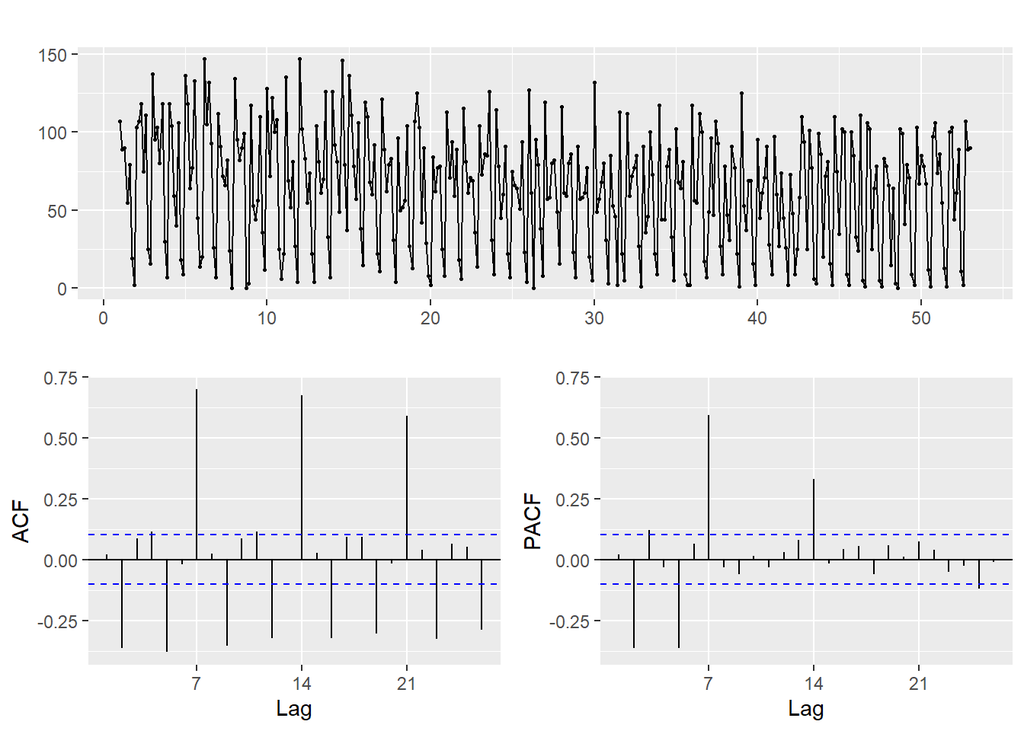

```r
ATM2_Weekly = ts(atm2, frequency = 7)

ggtsdisplay(ATM2_Weekly)
```

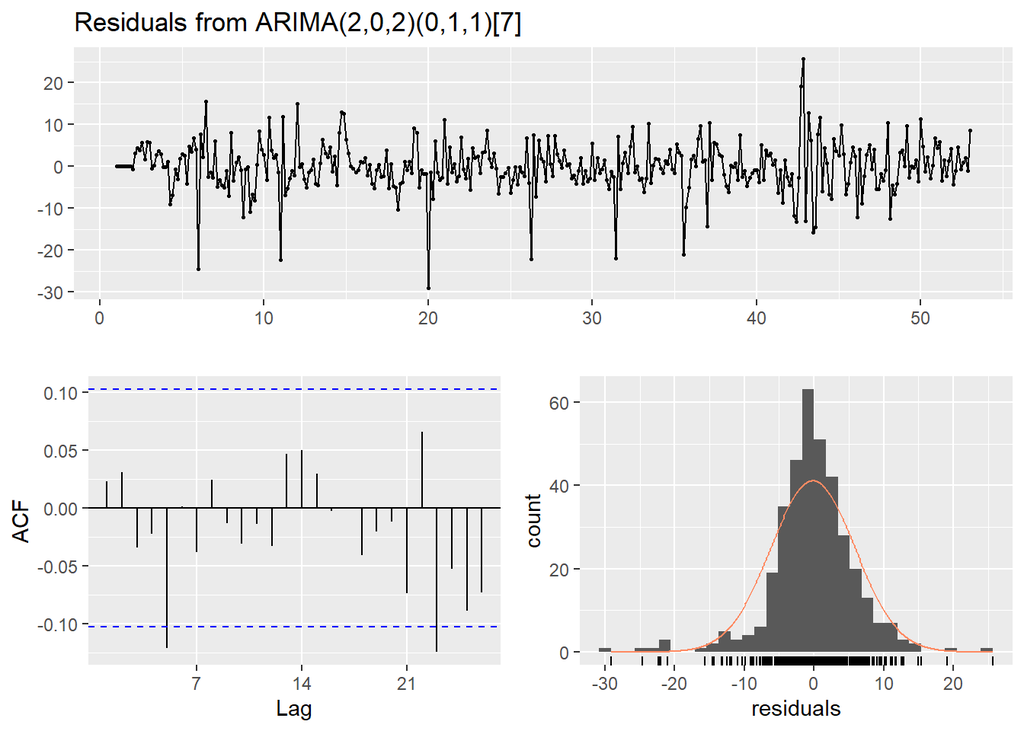

```
##
##  Ljung-Box test
##
## data:  Residuals from ARIMA(2,0,2)(0,1,1)[7]
## Q* = 10.046, df = 9, p-value = 0.3468
##
## Model df: 5.   Total lags used: 14
```

```r
Model1_ATM2_Weekly =auto.arima(ATM2_Weekly,lambda=BoxCox.lambda(ATM2_Weekly))
checkresiduals(Model1_ATM2_Weekly)
```

*Summary reveals the AIC is 2329.29, AICc is 2329.53 and BIC is 2352.57. The RMSE is 24.36601*

```r
summary(Model1_ATM2_Weekly)
```

```
## Series: ATM2_Weekly
## ARIMA(2,0,2)(0,1,1)[7]
## Box Cox transformation: lambda= 0.6498018
##
## Coefficients:
##           ar1      ar2     ma1     ma2     sma1
##       -0.4131  -0.8930  0.4475  0.7740  -0.7113
## s.e.   0.0605   0.0532  0.0895  0.0683   0.0419
##
## sigma^2 estimated as 38.01:  log likelihood=-1158.64
## AIC=2329.29   AICc=2329.53   BIC=2352.57
##
## Training set error measures:
##                     ME     RMSE      MAE  MPE MAPE      MASE        ACF1
## Training set 0.5811661 24.36601 16.99358 -Inf  Inf 0.8308795 -0.01297589
```

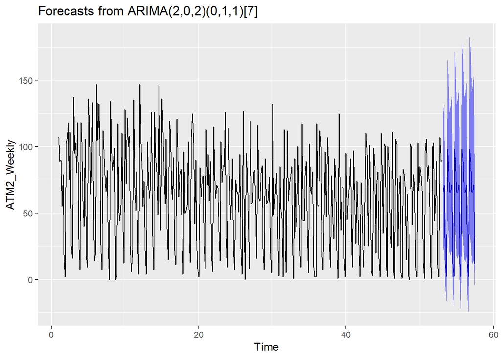

```r
autoplot(forecast(Model1_ATM2_Weekly, 31, level = 95))
```

```r
ATM2_Forecast = forecast(Model1_ATM2_Weekly, 31, level = 95)

F_ATM2 =data_frame(DATE = rep(max(atmdata$DATE) + 1:31),
           ATM = rep("ATM2"),
           Cash = as.numeric( ATM2_Forecast$mean) )
```

### ATM 3

*Model 3 was filtered with zero due to erroneous forecasting values.*

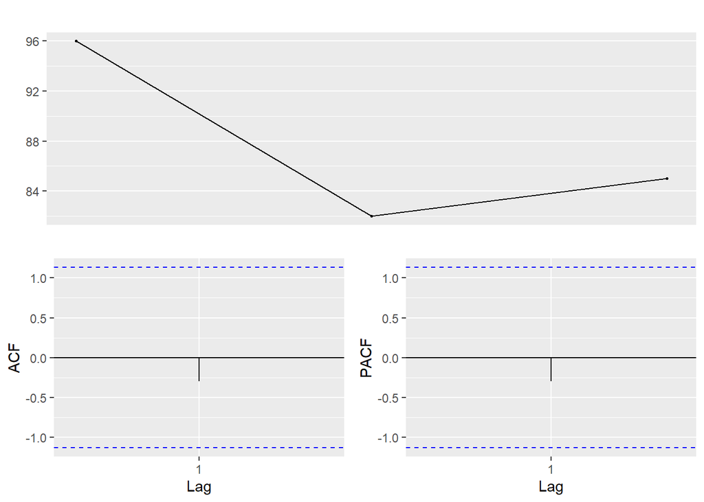

```r
ggtsdisplay(atm3)
```

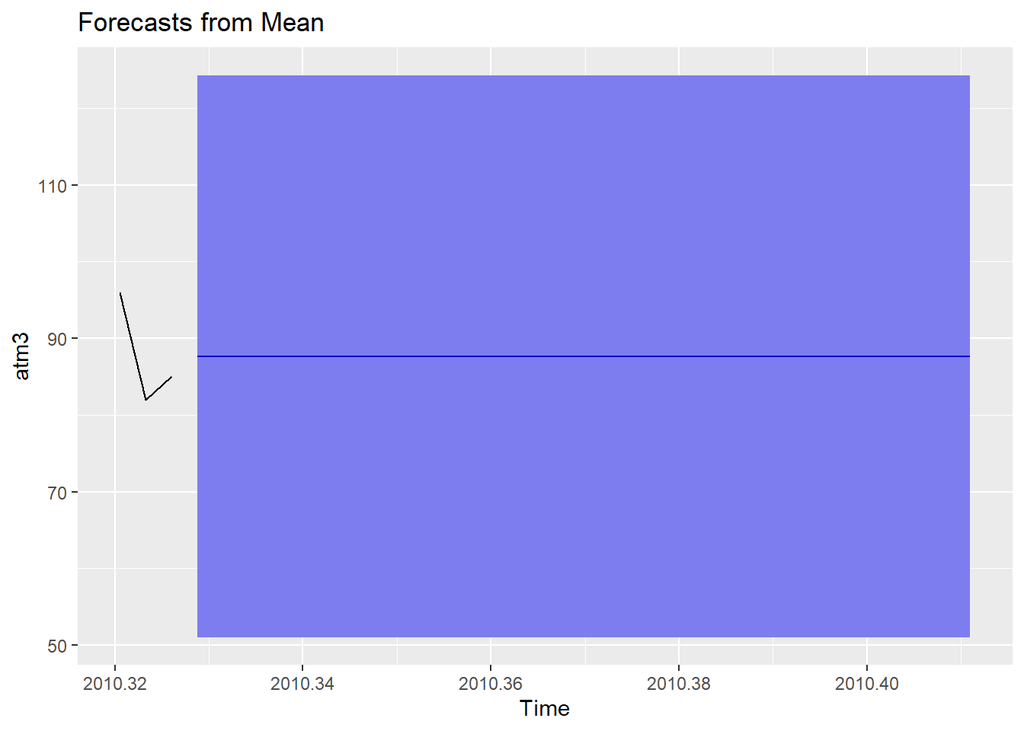

```r
ATM3_Forecast_fit = meanf(atm3, 31, level = 95)
autoplot(ATM3_Forecast_fit)
```

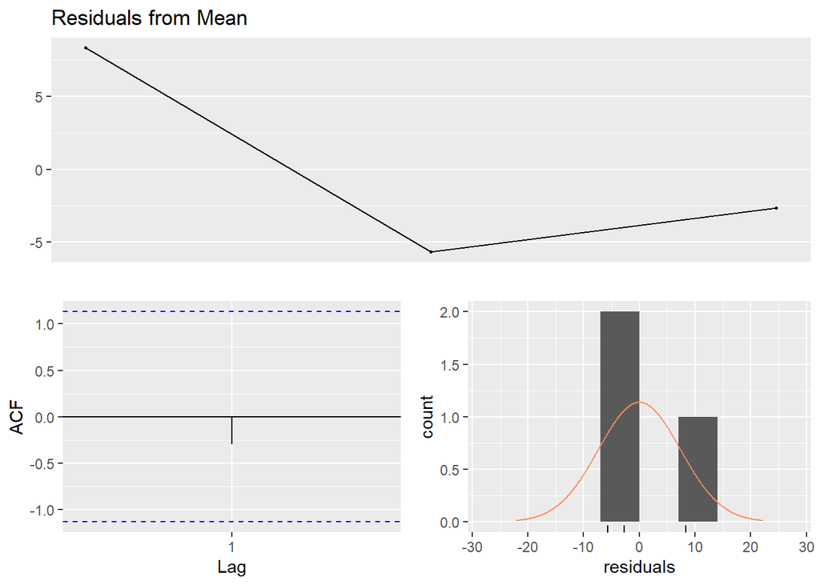

```
##
##  Ljung-Box test
##
## data:  Residuals from Mean
## Q* = NA, df = 3, p-value = NA
##
## Model df: 1.   Total lags used: 4
```

```r
checkresiduals(ATM3_Forecast_fit)
```

```r
summary(ATM3_Forecast_fit)
```

```
##
## Forecast method: Mean
##
## Model Information:
## $mu
## [1] 87.66667
##
## $mu.se
## [1] 4.255715
##
## $sd
## [1] 7.371115
##
## $bootstrap
## [1] FALSE
##
## $call
## meanf(y = atm3, h = 31, level = 95)
##
## attr(,"class")
## [1] "meanf"
##
## Error measures:
##                         ME    RMSE      MAE        MPE     MAPE MASE      ACF1
## Training set -4.737024e-15 6.01849 5.555556 -0.4557562 6.242793  NaN -0.295501
##
## Forecasts:
##           Point Forecast    Lo 95    Hi 95
## 2010.3288       87.66667 51.04494 124.2884
## 2010.3315       87.66667 51.04494 124.2884
## 2010.3342       87.66667 51.04494 124.2884
## 2010.3370       87.66667 51.04494 124.2884
## 2010.3397       87.66667 51.04494 124.2884
## 2010.3425       87.66667 51.04494 124.2884
## 2010.3452       87.66667 51.04494 124.2884
## 2010.3479       87.66667 51.04494 124.2884
## 2010.3507       87.66667 51.04494 124.2884
## 2010.3534       87.66667 51.04494 124.2884
## 2010.3562       87.66667 51.04494 124.2884
## 2010.3589       87.66667 51.04494 124.2884
## 2010.3616       87.66667 51.04494 124.2884
## 2010.3644       87.66667 51.04494 124.2884
## 2010.3671       87.66667 51.04494 124.2884
## 2010.3699       87.66667 51.04494 124.2884
## 2010.3726       87.66667 51.04494 124.2884
## 2010.3753       87.66667 51.04494 124.2884
## 2010.3781       87.66667 51.04494 124.2884
## 2010.3808       87.66667 51.04494 124.2884
## 2010.3836       87.66667 51.04494 124.2884
## 2010.3863       87.66667 51.04494 124.2884
## 2010.3890       87.66667 51.04494 124.2884
## 2010.3918       87.66667 51.04494 124.2884
## 2010.3945       87.66667 51.04494 124.2884
## 2010.3973       87.66667 51.04494 124.2884
## 2010.4000       87.66667 51.04494 124.2884
## 2010.4027       87.66667 51.04494 124.2884
## 2010.4055       87.66667 51.04494 124.2884
## 2010.4082       87.66667 51.04494 124.2884
## 2010.4110       87.66667 51.04494 124.2884
```

```r
F_ATM3 =data_frame(DATE = rep(max(atmdata$DATE) + 1:31),
           ATM = rep("atm3"),
           Cash = as.numeric( ATM3_Forecast_fit$mean))
```